# 11/06

2023-11-06

```r
getwd()
```

```
## [1] "C:/Users/avery/Documents/ds241/ds241_f23/bikeshare_23"
```

```r
library(tidyverse)
library(janitor)
library(here)
library(openmeteo)
library(lubridate)
```

## Read data

```r
BikeData = read_csv(here( "202309-capitalbikeshare-tripdata.csv"))
df2s=BikeData %>%
  select(rideable_type,member_casual,
                    contains("start"),ride_id) %>%
  mutate(start_stop="start") %>%
  rename(t=started_at,
         station_name=start_station_name,
         station_id=start_station_id,
         lat=start_lat,
         lng=start_lng)
df2e=BikeData %>%
  select(ride_id,rideable_type,member_casual,
                    contains("end")) %>%
  mutate(start_stop="stop") %>%
  rename(t=ended_at,
         station_name=end_station_name,
         station_id=end_station_id,
         lat=end_lat,
         lng=end_lng)

df2=bind_rows(df2s,df2e) %>%
  arrange(t) %>%
  mutate(rider_delta=(start_stop=="start")*2-1) %>% #change in ridership
  mutate(riders=cumsum(rider_delta)) %>%
  relocate(riders,.after=t)
```

## EDA Plots

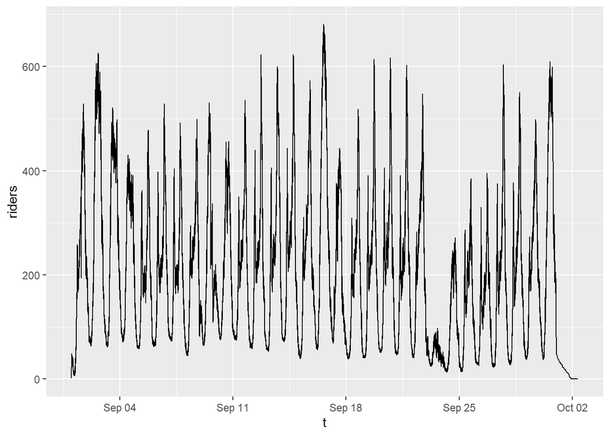

```r
df2 %>%
  ggplot(aes(t,riders)) +
  geom_line()
```

## Subsample Dataset

p1 is original data

```r
p1=df2 %>%
  filter(day(t)==18) %>%
  ggplot(aes(t,riders)) +
  geom_line() +
  ggtitle("Riders on 18Sep")
```

shrinking the amount of data to play with

```r
df_s=df2 %>% slice_head(n=1000)
```

rounding down to the nearest 10 minutes, then keeping a data point for each of the 10 minutes

```r
df_e=df_s |>
  mutate(t_f=floor_date(t,"10 mins")) %>%
  relocate(t_f,.after=t) %>%
  slice_head(n=1,by=t_f)
```

doing it on the entire data set (df reduced)

```r
df_r=df2 |>
  mutate(t_f=floor_date(t,"10 mins")) %>%
  relocate(t_f,.after=t) %>%
  slice_head(n=1,by=t_f)
```

red curve is drawn every 10 minutes

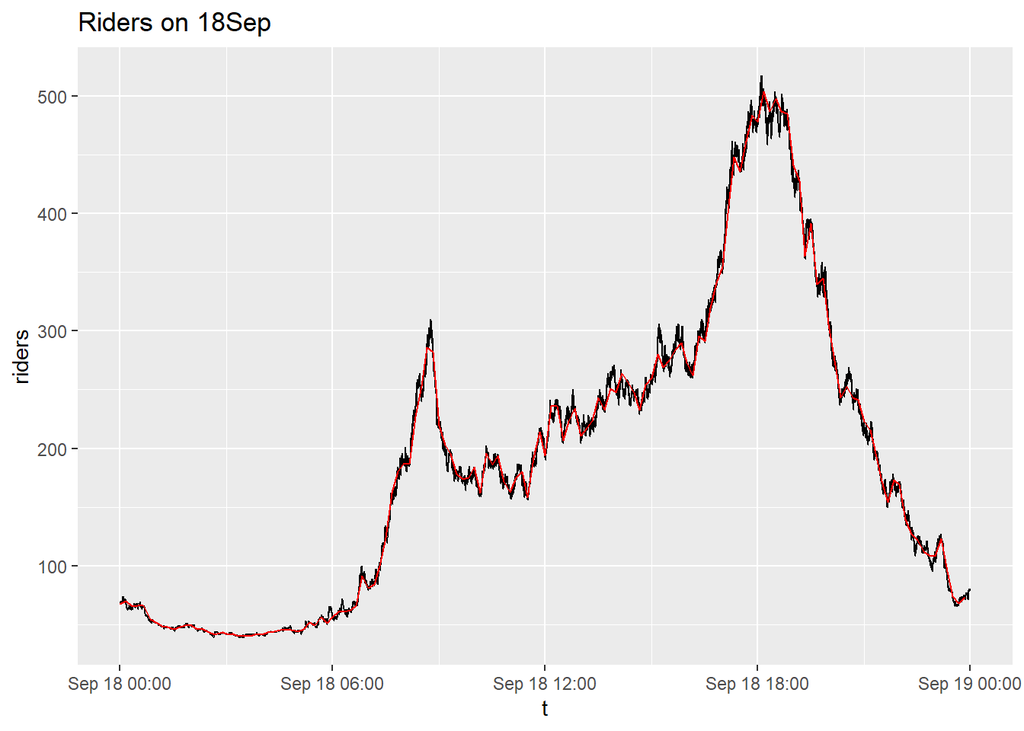

```r
p1+
  geom_line(data=df_r %>% filter(day(t)==18),
  color="red")
```

## Getting weather data

uses a function from open meteo to pull data from DC in the desired time period

```r
df_w=weather_history("Washington",
                    start = "2023-09-01",
                    end = "2023-09-30",
                    hourly = c("apparent_temperature",
                               "wind_speed_10m",
                               "precipitation")
)
```

```
## `geocode()` has matched "Washington" to:
## Washington in Washington, D.C., United States
## Population: 601723
## Co-ordinates: c(38.89511, -77.03637)
```

## merging bike and weather

play with a small amount of data to test if this works

```r
df_s=df2 %>% slice_sample(n=1000)
```

matching it with the closest match to t from df start

```r
df_j=df_s %>% left_join(df_w,
                        by=join_by(closest(t>=datetime)))
```

taking datetime to the right of t columns

```r
df_j=df_s %>%
  left_join(df_w,by=join_by(closest(t>=datetime)))  %>%
  relocate(datetime, .after=t)

head(df_j)
```

```
## # A tibble: 6 × 15
##   rideable_type member_casual t                   datetime            riders
##   <chr>         <chr>         <dttm>              <dttm>               <dbl>
## 1 classic_bike  member        2023-09-21 19:55:52 2023-09-21 15:00:00    352
## 2 electric_bike member        2023-09-03 21:48:21 2023-09-03 17:00:00    288
## 3 classic_bike  member        2023-09-22 22:46:48 2023-09-22 18:00:00     79
## 4 classic_bike  member        2023-09-26 19:39:25 2023-09-26 15:00:00    206
## 5 classic_bike  casual        2023-09-20 17:59:40 2023-09-20 13:00:00    559
## 6 classic_bike  casual        2023-09-20 08:50:11 2023-09-20 04:00:00    391
## # ℹ 10 more variables: station_name <chr>, station_id <dbl>, lat <dbl>,
## #   lng <dbl>, ride_id <chr>, start_stop <chr>, rider_delta <dbl>,
## #   hourly_apparent_temperature <dbl>, hourly_wind_speed_10m <dbl>,
## #   hourly_precipitation <dbl>
```

tells us why the previous code is not working (different time zones) Look at R for Data Science TimeZones

```r
df_j$t[1:5]
```

```
## [1] "2023-09-21 19:55:52 UTC" "2023-09-03 21:48:21 UTC"
## [3] "2023-09-22 22:46:48 UTC" "2023-09-26 19:39:25 UTC"
## [5] "2023-09-20 17:59:40 UTC"
```

```r
df_j$datetime[1:5]
```

```
## [1] "2023-09-21 15:00:00 EDT" "2023-09-03 17:00:00 EDT"
## [3] "2023-09-22 18:00:00 EDT" "2023-09-26 15:00:00 EDT"
## [5] "2023-09-20 13:00:00 EDT"
```

using package lubridate to equate the timezone

```r
df2$t[1:5]
```

```
## [1] "2023-09-01 00:00:44 UTC" "2023-09-01 00:01:48 UTC"
## [3] "2023-09-01 00:01:48 UTC" "2023-09-01 00:02:03 UTC"
## [5] "2023-09-01 00:02:21 UTC"
```

```r
force_tz(df2$t[1:5],"America/New_York")
```

```
## [1] "2023-09-01 00:00:44 EDT" "2023-09-01 00:01:48 EDT"
## [3] "2023-09-01 00:01:48 EDT" "2023-09-01 00:02:03 EDT"
## [5] "2023-09-01 00:02:21 EDT"
```

df 2 corrected times

```r
df2c=df2 %>% mutate(t=force_tz(t,tzone="America/New_York")) #corrected

df_s2=df2c %>% slice_sample(n=1000)

df_j2=df_s2 %>%
  left_join(df_w,by=join_by(closest(t>=datetime)))  %>%
  relocate(datetime, .after=t)

head(df_j2)
```

```
## # A tibble: 6 × 15
##   rideable_type member_casual t                   datetime            riders
##   <chr>         <chr>         <dttm>              <dttm>               <dbl>
## 1 classic_bike  member        2023-09-30 16:19:59 2023-09-30 16:00:00    554
## 2 electric_bike member        2023-09-15 19:50:35 2023-09-15 19:00:00    368
## 3 electric_bike casual        2023-09-24 18:16:13 2023-09-24 18:00:00    254
## 4 electric_bike casual        2023-09-15 10:48:45 2023-09-15 10:00:00    235
## 5 classic_bike  member        2023-09-08 13:18:20 2023-09-08 13:00:00    236
## 6 classic_bike  member        2023-09-13 13:28:13 2023-09-13 13:00:00    228
## # ℹ 10 more variables: station_name <chr>, station_id <dbl>, lat <dbl>,
## #   lng <dbl>, ride_id <chr>, start_stop <chr>, rider_delta <dbl>,
## #   hourly_apparent_temperature <dbl>, hourly_wind_speed_10m <dbl>,
## #   hourly_precipitation <dbl>
```

doing the above to the entire data set and renaming

```r
dfc = df2c %>%
  left_join (df_w, by=join_by(closest(t>=datetime))) %>%
  relocate(datetime, .after=t) %>%
  rename(atemp= hourly_apparent_temperature,
         wind = hourly_wind_speed_10m,
         prec=hourly_precipitation)
```

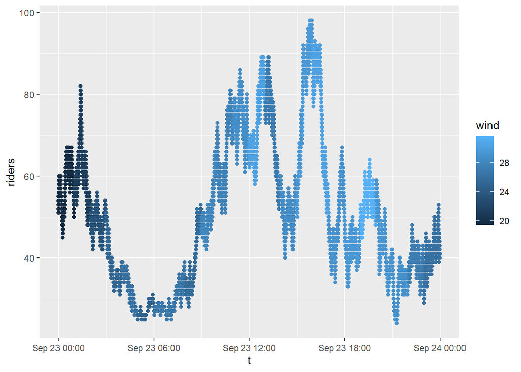

```r
p2=dfc %>%
  filter(day(t) == 23)%>% #SHOWS DATA FOR SEPT *date*
  ggplot(aes(t,riders,color=wind)) +
  geom_point()

p2
```

We want to find the difference between times in start and end (ride_time) make a scatter plot of the ride_time Think about what our cut offs should be in the data